# Sentence Comprehension

- Show All Code
- Hide All Code
- View Source

Task performance

Processing and analysis of the behavioural task during the EEG experiment. It was a sentence comprehension task (multiple choice questions) for familiar and unfamiliar speakers in quiet and in noise for 38 subjects.

Author

Valeriia Perepelytsa

Published

January 18, 2024

# General Comments

- Filename. Try to name your files with a descriptive, preferably pronounceable name
- Removed unnecessary ‘workspace’ variable from master file,
- file.path is used to build paths without having to specify OS separator (avoid setting sep if possible , for interoperability, the equivalent in Matlab is ‘fullfile’ ). This and relative paths are quite important and will save you lots of time. That is, do not hard code the entire path of file (or you will have to update that line everytime you move something). Use the position of the script to find the path where the data are.
- I shortened comments, also if you specify too much information in them when the code changes you will have to revise the comment as well. Often code changes and comments are not updated, informative variable names can help making the code self-explanatory requiring only minimal comments
- Avoid going to inputFolder with setwd(). Best practice is to refer to the fullpath when accessing data instead of changing your working directory
- Avoid visual overload with comments and title frames etc. Luckily with Quarto thats even less necessary. If in code I usually stick to underscoring the main sections with dashes ( - - - - - - )
- For convenience it is often best to keep all user inputs on the top of the script (e.g., defining output filename). Depending of the script I also tend to also leave the saving parts at the end ( easier debugging). Keep the user input that will be edited more frequently on a clear place, preferrably on top
- if possible specify the package before function, e.g., dplyr::bind_rows(df_list). Unless this makes everything too long and messy
- For plots. The less things you hard code, like the labels, the less chances for messing up labels. Let the data frame content and the plotting package define the labels of the axes and colors, e.g., use facet_grid or facet_wrap if ggplot

# Preprocessing

## Load libraries

In this example we load all required libs for this entire script.

But some times it may be better to load library for each code chunk (that way when you copy the code chunk it will work you have the info also about what libraries are required)

You can use the function ‘require’ (in the example below applied to a vector of package names). That will tell you if a package in the list is not install. You can install it manually rather than include code that may install packages. You can alternatively use a conditional that will install those not installed.

```r
packages <- c("tidyverse", "dplyr","ggplot2", "RColorBrewer", "DT", "rstatix")
sapply(packages,require,character.only=TRUE)
require(packages)

# Alternatively:
#new.packages <- packages[!(packages %in% installed.packages()[,"Package"])]
#if(length(new.packages)) install.packages(new.packages)
#library(new.packages)
```

## Set paths and user input

Here use file.path to avoid hardcoding the system separator: better interoperability

```r
# set paths
inputFolder = file.path(getwd(),'input')
outputFolder = file.path(getwd(),'output')

#output
outputname = "sentence_comprehen"
```

## Concatenate

**Error prevention tips**

- If possible, specify some pattern when searching for files, that will avoid taking the wrong files (e.g., If by accident or by choice I have other csv files in the same input folder, which I don’t want to concatenate)
- You may want some sanity check to verify that your files have the expected dimensions and or variables. This can help you spot errors when the files were generated or errors reading the wrong files. Alternatively you can print the values in the console to manually see if they make sense
- In Quarto (or R markdown) you can also print the values of interest in the text chunk
- In Quarto (or R markdown) you can render the data table for inspection, as an interactive with y-scroll so that it doesn’t take up too much space

```r
# read and concatenate
fileNames <- list.files(inputFolder, full.names = TRUE,pattern = 'P*_full.csv')
df_list <- lapply(fileNames, read.csv, header = TRUE, sep = ",", stringsAsFactors = FALSE)

# Check n cols
if (length(unique(sapply(df_list, ncol))) > 1) {
  stop("Not all data frames have the same number of columns!! ")
}

# bind rows
data <- dplyr::bind_rows(df_list)
```

A total of 38 files were read from C:/Users/gorka/Desktop/VALERIIA/tfaYNG_eegTask/logfiles/input.

They were concatenated into a 6081 x 8 array

Check it out !

```r
# render table
DT::datatable(data, options = list(dom = 't',
                                   scrollX = TRUE,
                                   scrollY= "400px",
                                   pageLength = 999999))
```

|  | participant | trial | file | speaker | condition | sentence | familiarity | response |
| --- | --- | --- | --- | --- | --- | --- | --- | --- |
| 1 | P01 | 1 | sp02_quiet_29 | sp02 | quiet | 29 | familiar | hit |
| 2 | P01 | 2 | sp01_quiet_26 | sp01 | quiet | 26 | familiar | hit |
| 3 | P01 | 3 | sp04_quiet_22 | sp04 | quiet | 22 | familiar | hit |
| 4 | P01 | 4 | sp03_quiet_69 | sp03 | quiet | 69 | familiar | hit |
| 5 | P01 | 5 | sp02_noisy_75 | sp02 | noisy | 75 | familiar | hit |
| 6 | P01 | 6 | sp03_noisy_42 | sp03 | noisy | 42 | familiar | incorrect |
| 7 | P01 | 7 | sp01_noisy_10 | sp01 | noisy | 10 | familiar | hit |
| 8 | P01 | 8 | sp01_noisy_01 | sp01 | noisy | 1 | familiar | hit |
| 9 | P01 | 9 | sp03_quiet_24 | sp03 | quiet | 24 | familiar | incorrect |
| 10 | P01 | 10 | sp02_quiet_04 | sp02 | quiet | 4 | familiar | hit |

[output cut: 6071 more lines]

# Analysis

## Summary statistics

Summarize, convert to wide format and computes percentage

```r
data_sum = data %>%
  group_by(participant, familiarity, condition, response) %>%
  count(response) %>%
  spread(response, n) # converts to wide format
# add percentage correct column
data_sum$percent = (data_sum$hit/40)*100

# render table
DT::datatable(data_sum, options = list(dom = 't',
                                   scrollX = TRUE,
                                   scrollY= "400px",
                                   pageLength = 999999))
```

|  | participant | familiarity | condition | V1 | hit | incorrect | percent |
| --- | --- | --- | --- | --- | --- | --- | --- |
| 1 |  |  |  | 1 |  |  |  |
| 2 | P01 | familiar | noisy |  | 30 | 10 | 75 |
| 3 | P01 | familiar | quiet |  | 35 | 5 | 87.5 |
| 4 | P01 | unfamiliar | noisy |  | 25 | 15 | 62.5 |
| 5 | P01 | unfamiliar | quiet |  | 37 | 3 | 92.5 |
| 6 | P02 | familiar | noisy |  | 29 | 11 | 72.5 |
| 7 | P02 | familiar | quiet |  | 33 | 7 | 82.5 |
| 8 | P02 | unfamiliar | noisy |  | 32 | 8 | 80 |
| 9 | P02 | unfamiliar | quiet |  | 33 | 7 | 82.5 |
| 10 | P03 | familiar | noisy |  | 24 | 16 | 60 |

[output cut: 143 more lines]

## Figures

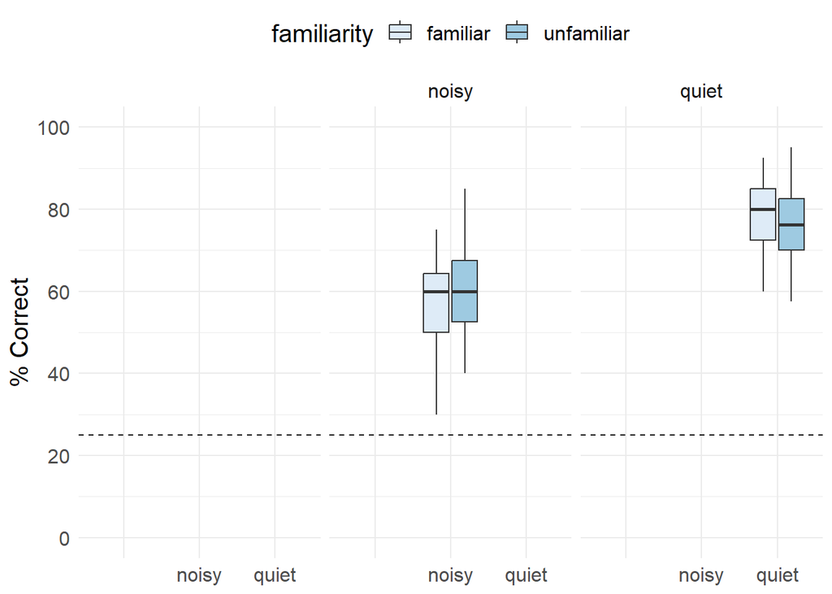

```r
fig <-
  ggplot(data_sum, aes(x=condition, y=percent, fill=familiarity)) +
  geom_boxplot() +
  ylab("% Correct") +
  theme_minimal() +
  facet_wrap(~condition) +
  scale_fill_brewer(palette = "Blues") +
  scale_y_continuous(limits = c(0, 100), breaks = c(0, 20, 40, 60, 80, 100)) + # set up y axis
  geom_hline(yintercept=25,linetype=2) + # add horizontal line indicating chance performance
  theme(text = element_text(size = 15)) + # increase text size
  theme(axis.title.x = element_blank()) + # remove x axis title
  theme(legend.position="top", legend.direction = "horizontal") # change legend position


fig
```

## 2-way anova on percent correct responses

```r
aov1 <- aov(percent ~ familiarity*condition + Error(participant), data = data_sum)
df_aov1 = as.data.frame(rstatix::anova_summary(aov1))
df_aov1
```

```
                 Effect DFn DFd       F        p p<.05   ges
1           familiarity   1 111   0.662 4.17e-01       0.006
2             condition   1 111 221.594 3.26e-28     * 0.666
3 familiarity:condition   1 111   2.399 1.24e-01       0.021
```

### Save stuff

```r
openxlsx::write.xlsx(data_sum, file.path(outputFolder,paste0(outputname, "_concat.xlsx")))
openxlsx::write.xlsx(data_sum, file.path(outputFolder,paste0(outputname, "_sum.xlsx")))
openxlsx::write.xlsx(df_aov1, file.path(outputFolder,paste0(outputname, "_anova.xlsx")))
ggplot2::ggsave(plot = fig, filename = file.path(outputFolder,paste0(outputname, "_fig.pdf")), width = 6,height = 5, units = "in")
```